# Ajuste de un modelo lineal simple de altura-diámetro

Christian Salas-Eljatib, Ph.D.

Email: cseljatib@gmail.com | Web: https://eljatib.com

Última actualización de este sitio: 09 enero, 2023

————————

## Contexto

El modelo de regresión lineal simple (SLR) es uno de los modelos estadísticos más usados en aplicaciones prácticas de diferentes disciplinas (Harrell, 2001). Acá se muestra como lograr el ajuste de un modelo SLR en el software R (R Core Team, 2022).

Un modelo estadístico lineal simple de altura ($h$)-diámetro ($d$) tiene la siguiente estructura general
$$\begin{equation}
h_i={\beta_0}+{\beta_1}d_i + \epsilon_i, \label{eq:modh.0}
\end{equation}$$
donde: $h_i$ es la altura del $i$-ésimo árbol; $d_i$ es el diámetro a la altura del pecho del $i$-ésimo árbol; ${\beta_0}$ y ${\beta_1}$ son parámetros del modelo que representan al intercepto y pendiente, respectivamente; $\epsilon_{i}$ es un error aleatorio para la $i$-ésima observación que sigue una función de densidad de probabilidades Gaussiana con valor esperado cero y varianza $\sigma^2_{\epsilon}$.

## Datos

Se empleará la dataframe ${\tt idahohd2}$ del paquete ${\tt datana}$ (Salas-Eljatib *et al.*, 2022) del libro **Análisis de datos con el programa estadístico R: una introducción aplicada** (Salas-Eljatib, 2021). Esta dataframe contiene mediciones de altura y diámetro de árboles dentro de parcelas de muestreo en bosques naturales del Estado de Idaho (USA).

```r
> library(datana)
> data("idahohd2")
> df <- idahohd2
```

Revisemos los datos

```r
> head(df) #primeras seis filas
```

```
  parce narb spp  d    h
1     2    1  DF 39 20.5
2     2    2  WL 48 33.0
3     3    2  GF 52 30.0
4     3    5  WC 36 20.7
5     3    8  WC 38 22.5
6     4    1  WC 46 18.0
```

```r
> nrow(df) #numero de filas de la dataframe
```

```
[1] 372
```

Una estadística descriptiva de las variable predictora y respuesta se obtiene mediante la función ${\tt descstat()}$

```r
> descstat(df[,c("d","h")])
```

```
                d       h
n         372.000 372.000
Minimum    10.000   5.000
Maximum   112.000  48.000
Mean       36.628  24.313
Median     33.750  24.500
Std. Dev.  18.159   7.382
CV %       49.576  30.365
```

Es fundamental revisar la dispersión entre la variable respuesta y la predictora

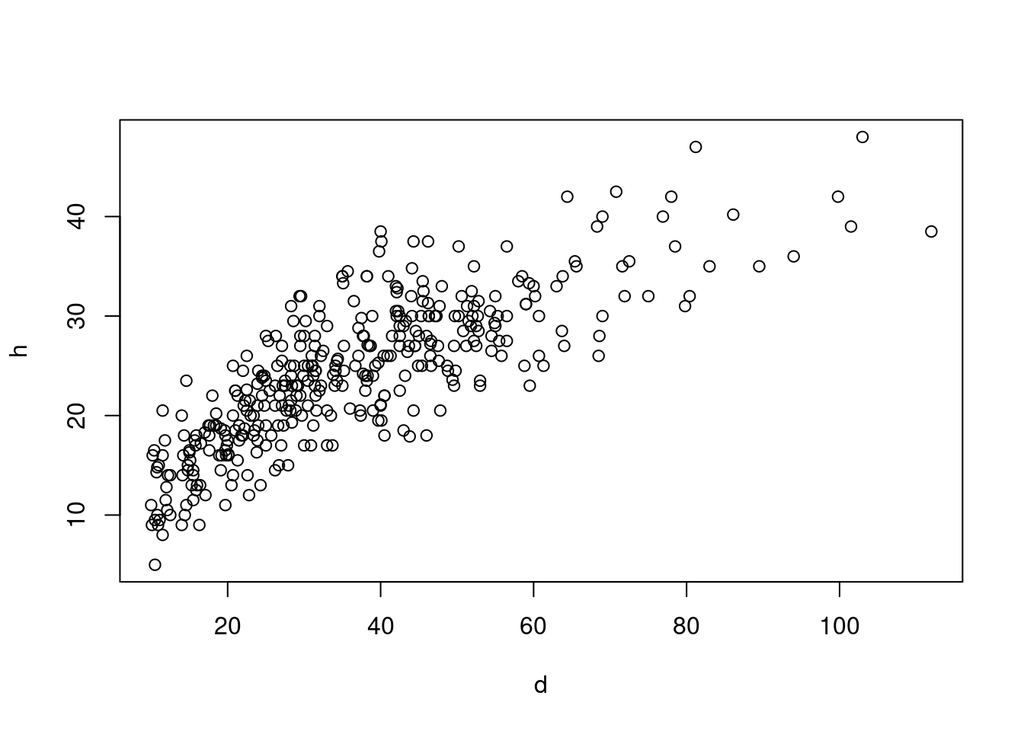

```r
> plot(h~d, data=df)
```

## Ajuste del modelo de regresión lineal simple

Se ajustará el modelo mediante el método de los mínimos cuadrados (OLS), el cual esta implementado en la función ${\tt lm()}$ de R.

```r
> mod<- lm(h ~ d, data=df)
> summary(mod)
```

```
Call:
lm(formula = h ~ d, data = df)

Residuals:
   Min     1Q Median     3Q    Max
-10.81  -2.85  -0.01   2.59  13.09

Coefficients:
            Estimate Std. Error t value Pr(>|t|)
(Intercept)  12.3902     0.5176    23.9   <2e-16
d             0.3255     0.0127    25.7   <2e-16

Residual standard error: 4.43 on 370 degrees of freedom
Multiple R-squared:  0.641, Adjusted R-squared:  0.64
F-statistic:  661 on 1 and 370 DF,  p-value: <2e-16
```

El estimador del parámetro $\beta_0$ es 12.3902, mientras que el estimador del parámetro $\beta_1$ es 0.3255. El valor estimado para la desviasión estándar de los residuales $\sigma_{\epsilon}$ del modelo es 4.43, por lo tanto la varianza estimada de los residuales es 19.62.

## Referencias bibliográficas

Harrell F.E. Jr. (2001). Regression modeling strategies with applications to linear models, logistic regression, and survival analysis. Springer, New York, NY, USA.

R Core Team (2022). R: A language and environment for statistical computing. R Foundation for Statistical Computing, Vienna, Austria. http://www.R-project.org.

Salas-Eljatib C. (2021). Análisis de datos con el programa estadístico R: una introducción aplicada. Ediciones Universidad Mayor, Santiago, Chile. 170 p. https://tienda.zigzag.cl/9789566086109-analisis-de-datos-con-el-programa-estadistico-r.html.

Salas-Eljatib C., Riquelme J. & Pino N. (2022). `datana`: Data and functions to accompany Análisis de datos con R. Package version 1.0.2. https://cran.r-project.org/package=datana.